# EDA_data_association

## 전체 투표참여량

- raw dataset의 투표참여량

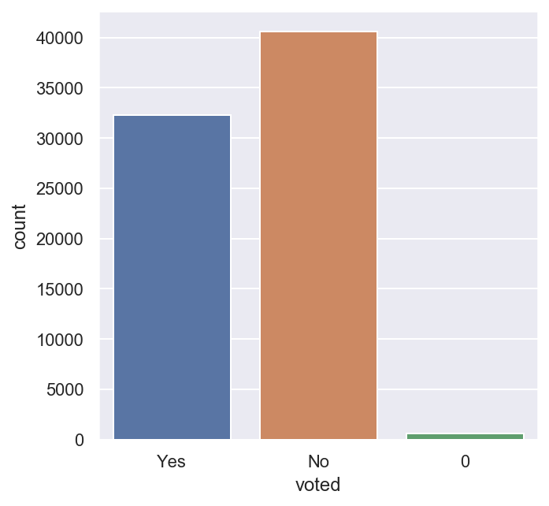

```python
plt.figure(figsize=(5, 5))
sns.countplot(x=df['voted']);
```

- 선거가능연령 dataset의 투표참여량

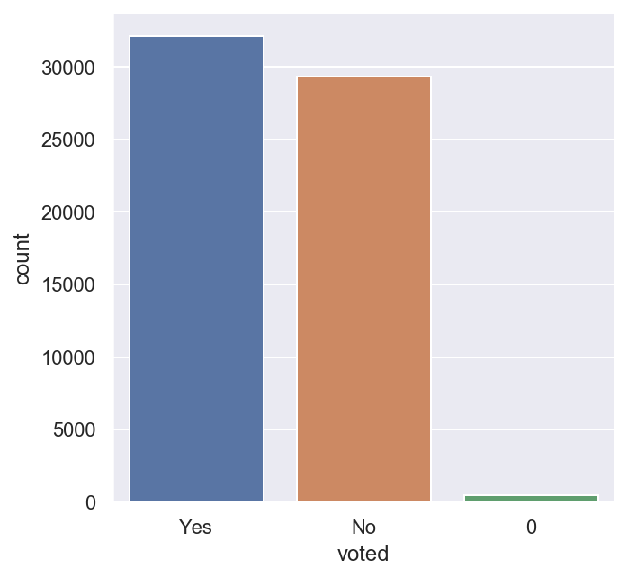

```python
plt.figure(figsize=(5, 5))
sns.countplot(x=df['voted']);
```

## Feature별 투표 참여량 & 참여율

### QA

- MACH-IV 각 질문지 답변별 투표참여량

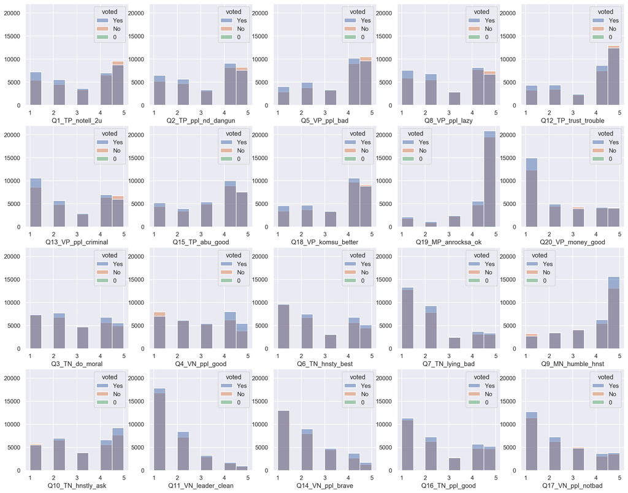

```python
figure, ((ax1,ax2,ax3,ax4,ax5), (ax6,ax7,ax8,ax9,ax10), (ax11, ax12, ax13, ax14, ax15), (ax16, ax17, ax18, ax19, ax20)) = plt.subplots(nrows=4, ncols=5)
figure.set_size_inches(20,16)

for n, c in enumerate(pos_col):
    ax = globals()["ax" + '{}'.format(n+1)]
    plt_ = sns.histplot(df, x=c, hue='voted', binwidth=0.5, ax=ax)
    plt_.set(ylabel="", ylim=(0, 22000))

for n, c in enumerate(neg_col):
    ax = globals()["ax" + '{}'.format(n+11)]
    plt_= sns.histplot(df, x=c, hue='voted', binwidth=0.5, ax=ax)
    plt_.set(ylabel="", ylim=(0, 22000))
```

### QI

- MACH-IV 각 질문지 위치별 투표참여량

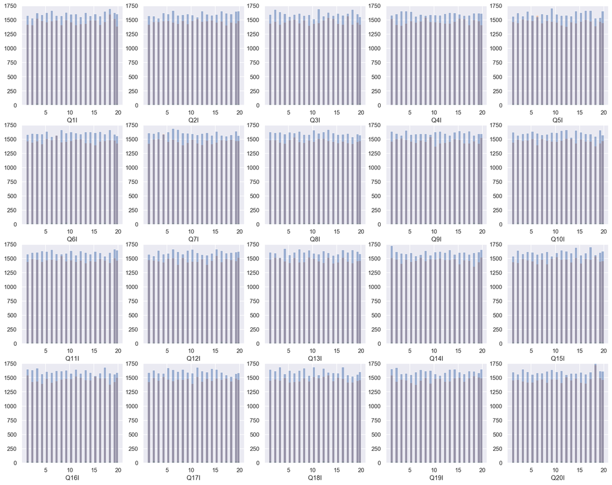

```python
figure, ((ax1,ax2,ax3,ax4,ax5), (ax6,ax7,ax8,ax9,ax10), (ax11, ax12, ax13, ax14, ax15), (ax16, ax17, ax18, ax19, ax20)) = plt.subplots(nrows=4, ncols=5)
figure.set_size_inches(20,16)

for n, c in enumerate(i_col):
    ax = globals()["ax" + '{}'.format(n+1)]
    plt_ = sns.histplot(df, x=c, hue='voted', binwidth=0.5, ax=ax, legend=False)
    plt_.set(ylabel="", ylim=(0, 1750))
```

### QE

- MACH-IV 각 질문지별 답변시간 분포

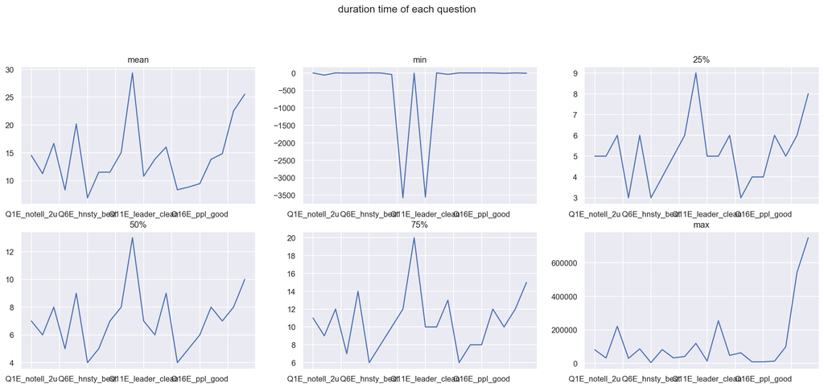

```python
plt.figure(figsize=(20, 12))
plt.suptitle('duration time of each question')

plt.subplot(331)
df_QE.describe().loc['mean'].plot(kind='line')
plt.gca().set_title('mean');

plt.subplot(332)
df_QE.describe().loc['min'].plot(kind='line')
plt.gca().set_title('min');

plt.subplot(333)
df_QE.describe().loc['25%'].plot(kind='line')
plt.gca().set_title('25%');

plt.subplot(334)
df_QE.describe().loc['50%'].plot(kind='line')
plt.gca().set_title('50%');

plt.subplot(335)
df_QE.describe().loc['75%'].plot(kind='line')
plt.gca().set_title('75%');

plt.subplot(336)
df_QE.describe().loc['max'].plot(kind='line')
plt.gca().set_title('max');
```

### score

- MACH-IV 답변 통합 점수

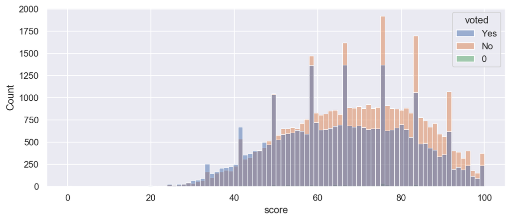

```python
plt.figure(figsize=(10, 4))
sns.histplot(df, x='score', hue='voted');
```

### TYP

- 성격 일치 수준별 투표참여량

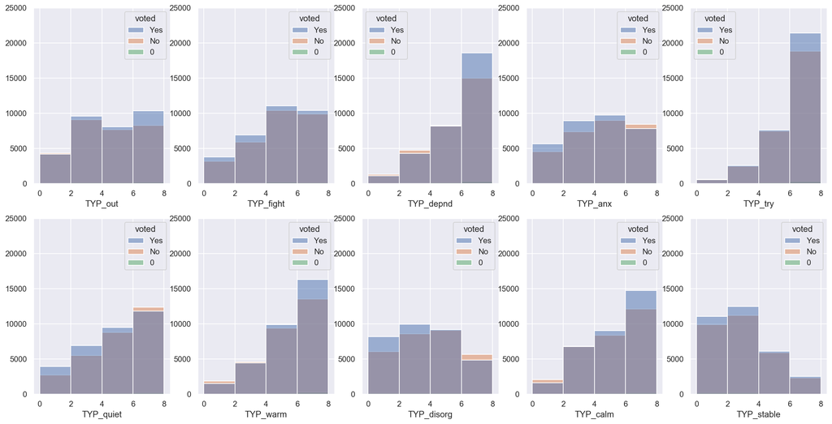

```python
figure, ((ax1,ax2,ax3,ax4,ax5), (ax6,ax7,ax8,ax9,ax10)) = plt.subplots(nrows=2, ncols=5)
figure.set_size_inches(20,10)

for n, c in enumerate(typ_col):
    ax = globals()["ax" + '{}'.format(n+1)]

    plt_ = sns.histplot(df, x=c, hue='voted', binwidth=2, ax=ax)
    plt_.set(ylabel="", ylim=(0, 25000))
```

### VCL

- 단어별 인지 여부에 따른 투표참여량

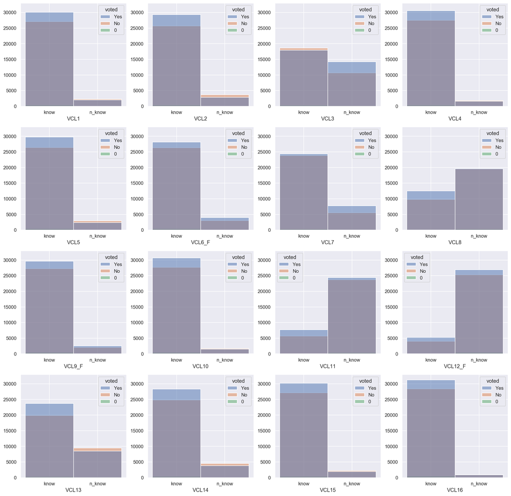

```python
label = ["know", "n_know"]
index=np.arange(len(label))

plt.figure(figsize=(20, 20))
for i in range(16):
    plt.subplot(4, 4, i+1)
    plot1 = sns.histplot(x=df_vcl[df_vcl.columns[i]], hue=df_vcl['voted'])
    plot1.set(ylabel="", ylim=(0, 33000))
    plt.xticks(index, label)
plt.show()
```

### education

- 교육 수준에 따른 투표참여량

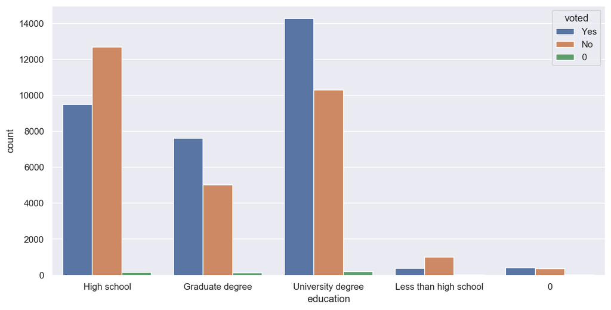

```python
plt.figure(figsize=(12, 6))
sns.countplot(x=df['education'], hue=df['voted']);
```

- 교육 수준에 따른 투표참여율

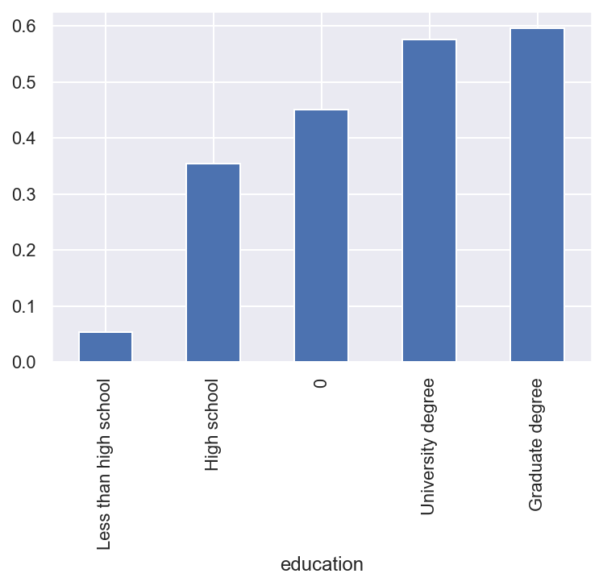

```python
test.voting_rates("education");
```

### hometown

- 출신지역에 따른 투표참여량

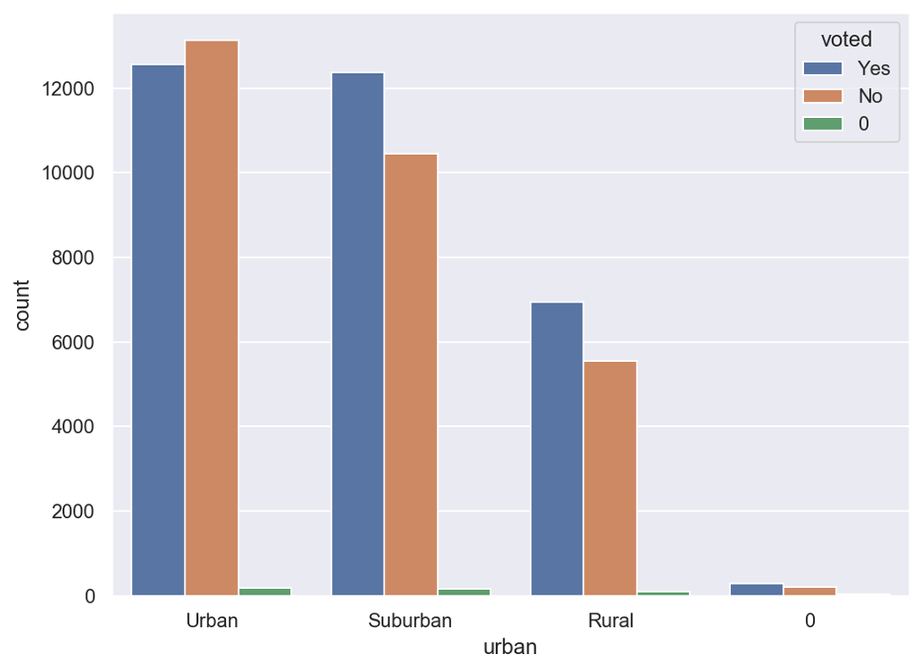

```python
plt.figure(figsize=(8, 6))
sns.countplot(x=df['urban'], hue=df['voted']);
```

- 출신지역에 따른 투표참여율

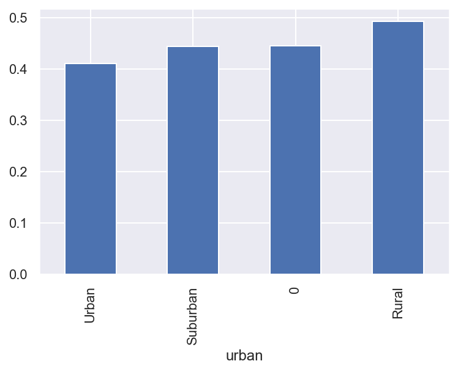

```python
test.voting_rates("urban");
```

### gender

- 성별에 따른 투표참여량

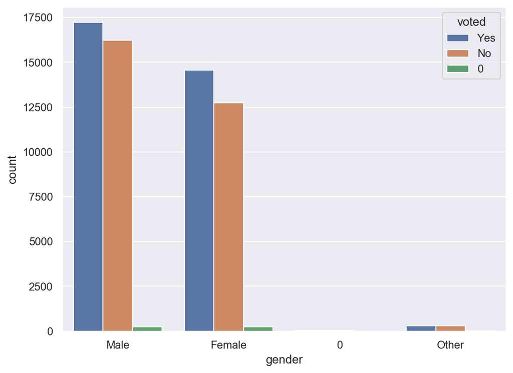

```python
plt.figure(figsize=(8, 6))
sns.countplot(x=df['gender'], hue=df['voted']);
```

- 성별에 따른 투표참여율

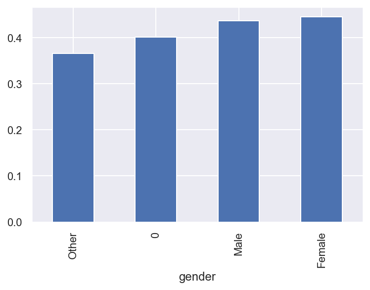

```python
test.voting_rates("gender");
```

### first language

- 모국어 영어 여부에 따른 투표참여량

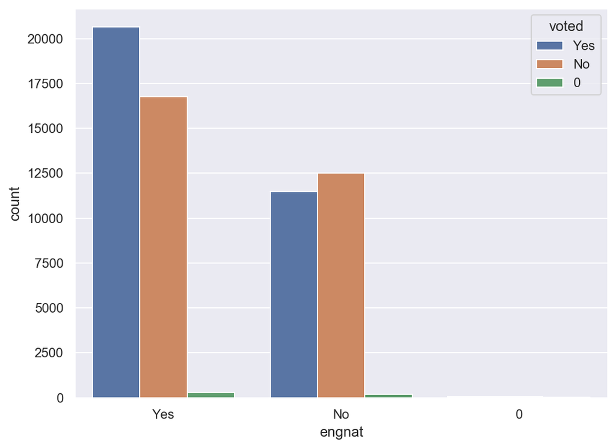

```python
plt.figure(figsize=(8, 6))
sns.countplot(x=df['engnat'], hue=df['voted']);
```

- 모국어 영어 여부에 따른 투표참여율

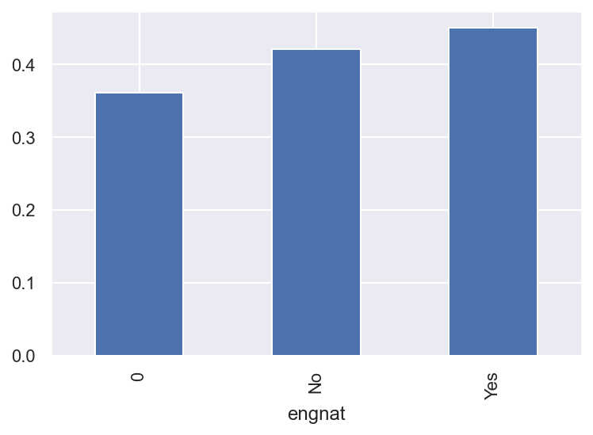

```python
test.voting_rates("engnat");
```

### age

- 나이별 투표참여량

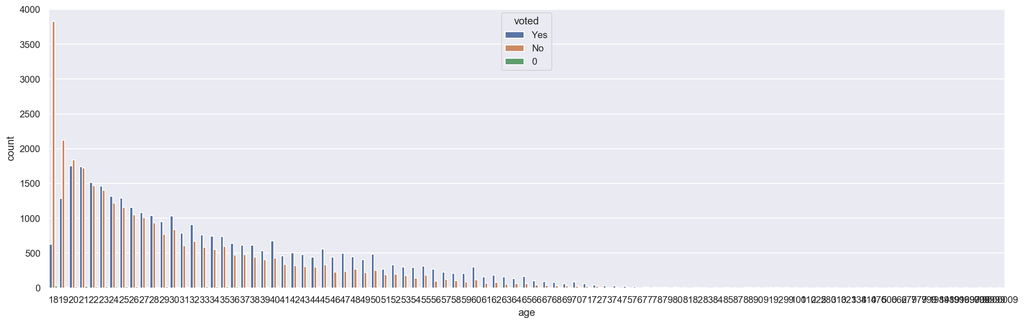

```python
plt.figure(figsize=(20, 6))
sns.countplot(x=df['age'], hue=df['voted']);
```

- 나이에 따른 투표참여율

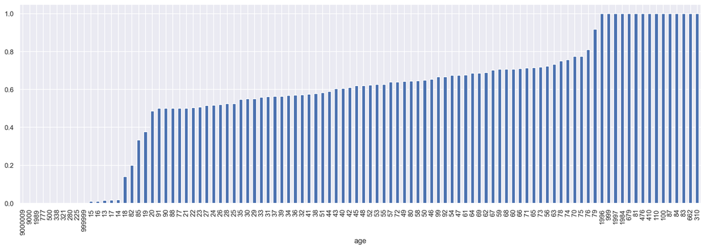

```python
plt.figure(figsize=(20, 6))
test.voting_rates("age");
```

### hand

- 주 사용손에 따른 투표참여량

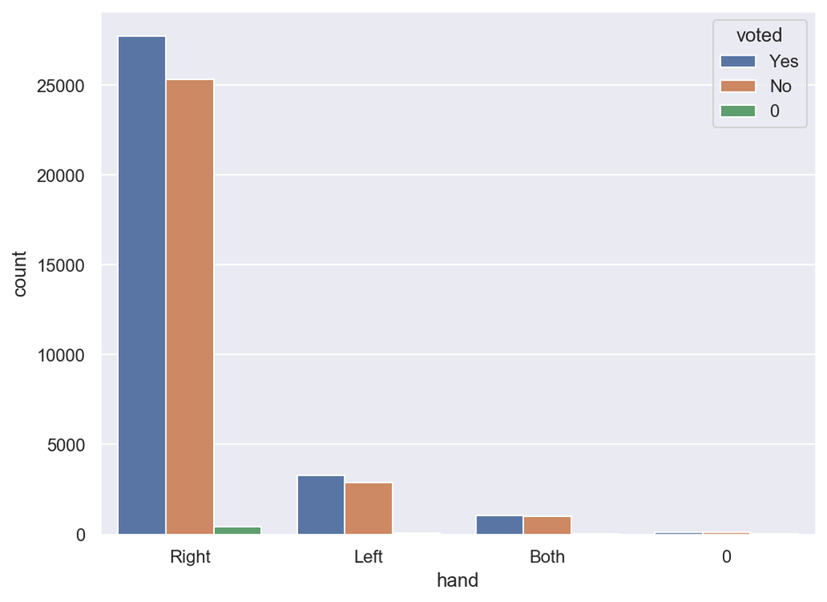

```python
plt.figure(figsize=(8, 6))
sns.countplot(x=df['hand'], hue=df['voted']);
```

- 주 사용손에 따른 투표참여율

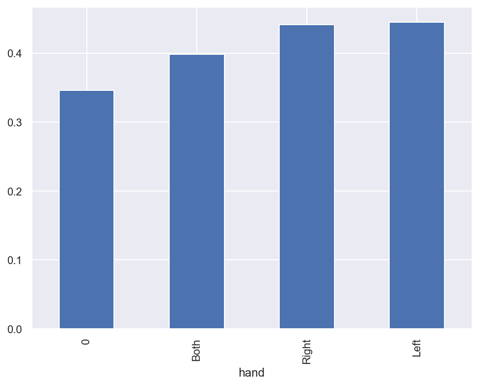

```python
plt.figure(figsize=(8, 6))
test.voting_rates("hand");
```

### religion

- 종교에 따른 투표참여량

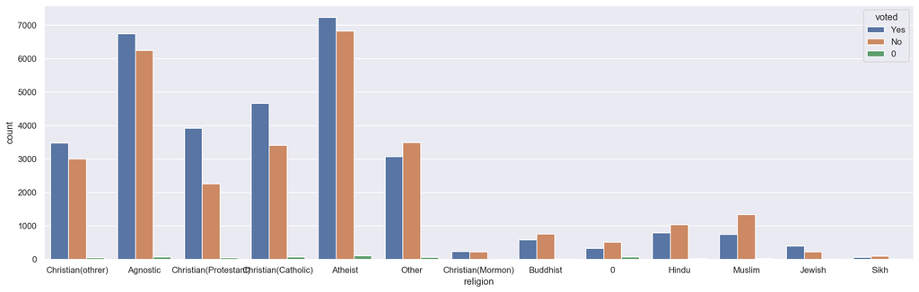

```python
plt.figure(figsize=(20, 6))
sns.countplot(x=df['religion'], hue=df['voted']);
```

- 종교에 따른 투표참여율

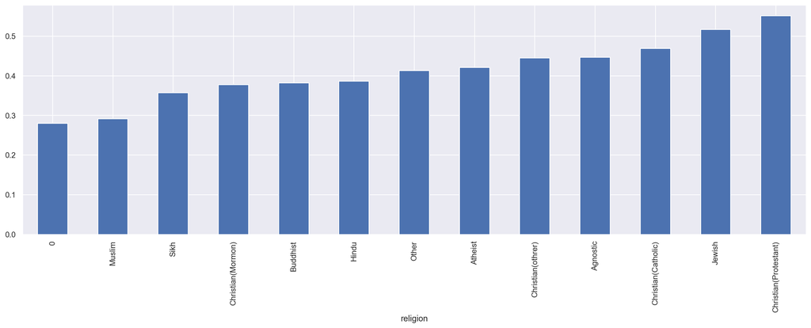

```python
plt.figure(figsize=(20, 6))
test.voting_rates("religion");
```

### orientation

- 성정체성에 다른 투표참여량

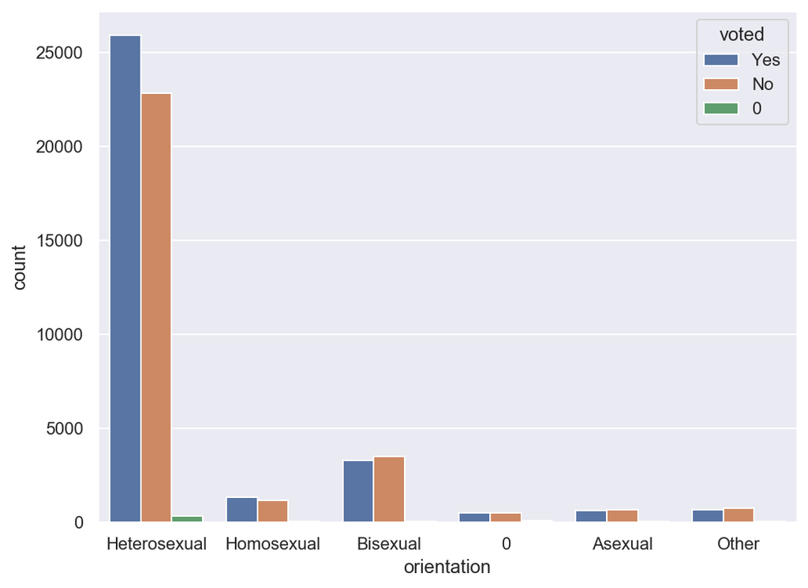

```python
plt.figure(figsize=(8, 6))
sns.countplot(x=df['orientation'], hue=df['voted']);
```

- 성정체성에 따른 투표참여율

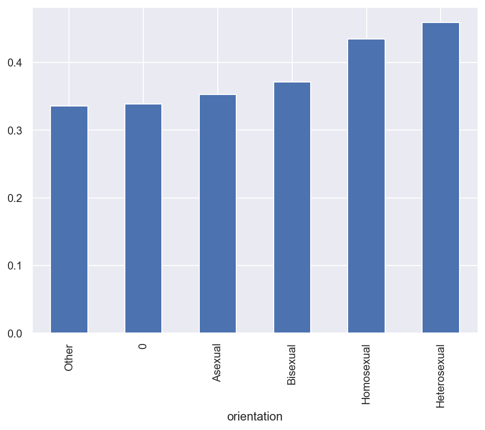

```python
plt.figure(figsize=(8, 6))
test.voting_rates("orientation");
```

### race

- 인종에 다른 투표참여량

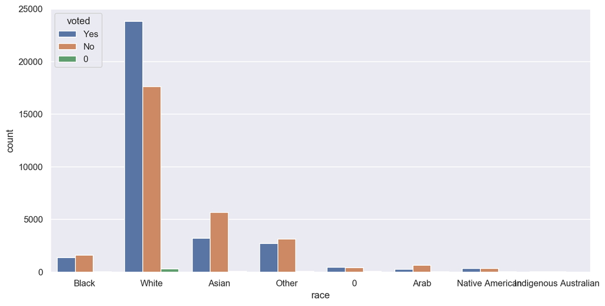

```python
plt.figure(figsize=(12, 6))
sns.countplot(x=df['race'], hue=df['voted']);
```

- 인종에 따른 투표참여율

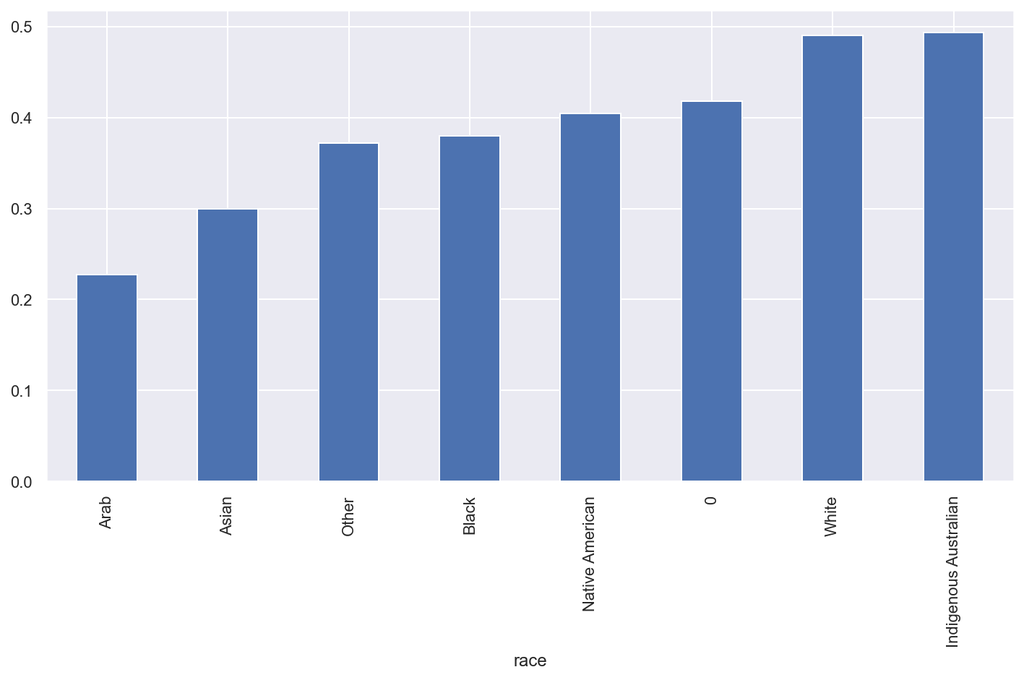

```python
plt.figure(figsize=(12, 6))
test.voting_rates("race");
```

### married

- 결혼여부에 따른 투표참여량

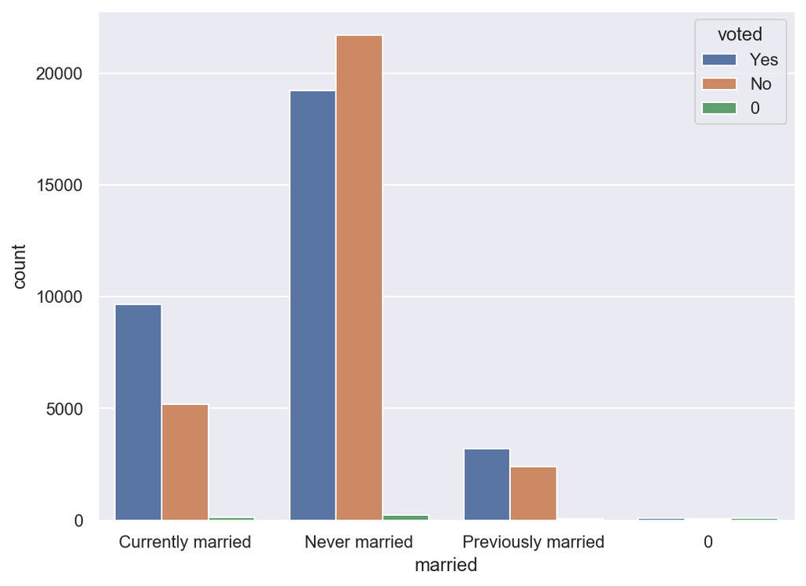

```python
plt.figure(figsize=(8, 6))
sns.countplot(x=df['married'], hue=df['voted']);
```

- 결혼여부에 따른 투표참여율

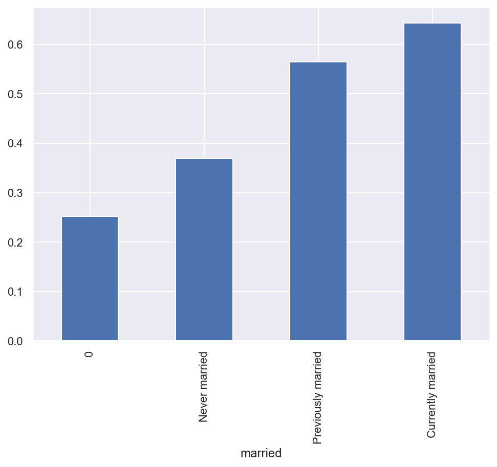

```python
plt.figure(figsize=(8, 6))
test.voting_rates("married");
```